# Question C

Feature Selection: 1) rimozione di attributi correlati tra loro (> di una certa soglia) 2) procedura stepAIC per determinare il miglior sottoinsieme di attributi, AIC è una stima della bontà del modello (considera il model fit e la semplicità del modello)

```r
library
```

[output not shown]

[output cut: 330 more lines]

[output not shown]

```r
#install.packages("caret", dep = TRUE)
library(lattice)
library(ggplot2)
library(data.table)
library(caret)
library(glmnet)
```

```r
aida = fread("aida_preproc.csv")
```

[output not shown]

```r
# Make the operator
'%!in%' <- function(x,y)!('%in%'(x,y))

# Add new empty column
aida$Failed <- NULL
```

```
Column 'Failed' does not exist to remove
```

```r
# For each 'Legal status' which contains 'Active' substring fill in new column 'No' else 'Yes'
act_vector <- c('Active','Active (default of payments)','Active (receivership)')
aida[aida$Legal.status %in% act_vector,'Failed'] <- 0
aida[aida$Legal.status %!in% act_vector,'Failed'] <- 1

aida[is.na(aida$Failed), ]
```

| Year | Incorporation.year | Company.name | File | Tax.code.number | ATECO.2007code | Legal.form | Legal.status | Province | Comune.ISTAT.code | Region | Banks/turnover | Cash.Flowth | Cost.of.debit | Current.liabilities/Tot.ass | Current.ratio | Debt/EBITDA.ratio | Debt/equity.ratio | EBITDA/Vendite | EBITDAth | Interest/Turnover | Leverage | Liquidity.ratio | Net.financial.positionth | Net.working.capitalth | Number.of.employees | Profit.(loss)th | ROA | ROE | ROI | … |
| --- | --- | --- | --- | --- | --- | --- | --- | --- | --- | --- | --- | --- | --- | --- | --- | --- | --- | --- | --- | --- | --- | --- | --- | --- | --- | --- | --- | --- | --- | --- |

```r
aida$Failed <- as.factor(aida$Failed)

drops <- c('Company.name','File','Tax.code.number','Legal.form','Legal.status','Comune.ISTAT.code','Region','Province')
aida <- subset(aida, select = -c(Company.name,ATECO.2007code,File,Tax.code.number,Legal.form,Legal.status,Comune.ISTAT.code,Region,Province))
```

Data Partitioning

```r
#create subsample of the dataset
sample = rbinom(nrow(aida), 1, .1)
data = aida[sample==1,]


#dummies <- dummyVars( ~ ., data = data)
#head(predict(dummies, newdata = data))
```

```r
set.seed(42)
trainIndex <- createDataPartition(data$Failed, p = .7,
                                  list = FALSE,
                                  times = 1)

aidaTrain <- data[ trainIndex,]
aidaTest  <- data[-trainIndex,]

table(aidaTrain$Failed)
```

```
     0      1
249758 148031
```

```r
down.aidaTrain <- downSample(x = aidaTrain, y = aidaTrain$Failed)
down.aidaTrain <- subset(down.aidaTrain, select = -c(Class))
table(down.aidaTrain$Failed)
```

```
     0      1
148031 148031
```

1. Un problema dei modelli lineari è l’alta correlazione tra le variabili indipendenti, prima di costruire il regresore logistico si cerca di escludere le variabili con correlazione > di una certa soglia
- In caso di correlazione tra due variabili, si elimina quella con VIF (Variance Inflation Factor) maggiore
- In alternativa, il metodo findCorrelation della libreria caret, restituisce direttamente le variabili da escludere sulla base della mean absolute correlation (“https://www.rdocumentation.org/packages/caret/versions/6.0-88/topics/findCorrelation”), oltre che le coppie di variabili che superano la soglia prestabilita

```r
corr.matrix=cor(subset(na.omit(aida), select = -c(Failed)))
#corr.matrix[abs(corr.matrix) < 0.8] = NA
#View(corr.matrix)
to.remove = findCorrelation(corr.matrix, cutoff = .8, verbose = TRUE, names=TRUE)
```

```
Compare row 19  and column  21 with corr  0.859
  Means:  0.153 vs 0.106 so flagging column 19
Compare row 17  and column  15 with corr  0.812
  Means:  0.154 vs 0.102 so flagging column 17
Compare row 4  and column  18 with corr  0.902
  Means:  0.124 vs 0.099 so flagging column 4
Compare row 15  and column  16 with corr  0.916
  Means:  0.092 vs 0.098 so flagging column 16
Compare row 14  and column  7 with corr  0.811
  Means:  0.132 vs 0.098 so flagging column 14
All correlations <= 0.8
```

```r
to.remove
```

```
[1] "ROA"                   "Number.of.employees"   "Cash.Flowth"           "Liquidity.ratio"
[5] "Net.working.capitalth"
```

```r
#data = subset(data, select = -c(Cash.Flowth, EBITDAth, Total.assetsth, ROA, Liquidity.ratio))
```

```r
colnames(data)
```

```
 [1] "Year"                          "Incorporation.year"            "Banks/turnover"
 [4] "Cash.Flowth"                   "Cost.of.debit"                 "Current.liabilities/Tot.ass"
 [7] "Current.ratio"                 "Debt/EBITDA.ratio"             "Debt/equity.ratio"
[10] "EBITDA/Vendite"                "EBITDAth"                      "Interest/Turnover"
[13] "Leverage"                      "Liquidity.ratio"               "Net.financial.positionth"
[16] "Net.working.capitalth"         "Number.of.employees"           "Profit.(loss)th"
[19] "ROA"                           "ROE"                           "ROI"
[22] "ROS"                           "Solvency.ratio"                "Total.assets.turnover.(times)"
[25] "Total.assetsth"                "Failed"
```

Si guarda al valore di VIF, le variabili con valore alto devono essere rimosse

```r
library(car)
noresampling = trainControl(method="none")

lr.fit = glm(Failed ~ ., data = na.omit(aidaTrain), family=binomial("logit"))

vif(lr.fit)
```

```
                           Year              Incorporation.year                `Banks/turnover`
                       1.065915                        1.096758                        3.914584
                    Cash.Flowth                   Cost.of.debit   `Current.liabilities/Tot.ass`
                      32.598405                        2.226649                        1.480019
                  Current.ratio             `Debt/EBITDA.ratio`             `Debt/equity.ratio`
                       3.351972                        1.012275                        2.491841
               `EBITDA/Vendite`                        EBITDAth             `Interest/Turnover`
                       2.587155                       37.294087                        4.102028
                       Leverage                 Liquidity.ratio        Net.financial.positionth
                       2.449693                        2.856312                        3.186882
          Net.working.capitalth             Number.of.employees               `Profit.(loss)th`
                       4.519377                        2.858010                        2.181304
                            ROA                             ROE                             ROI
                       6.033516                        1.606918                        5.056100
                            ROS                  Solvency.ratio `Total.assets.turnover.(times)`
                       3.930713                        1.690504                        1.612187
                 Total.assetsth
                       9.238755
```

Logistic regression con trainingset originale (leggermente sbilanciato)

```r
# resampling method
noresampling = trainControl(method="none")

lr.fit = train(Failed ~ ., data = na.omit(aidaTrain),
               method = "glmStepAIC", trControl=noresampling,
               # pass-trough options
               family=binomial(logit))
```

```
Start:  AIC=27588.75
.outcome ~ Year + Incorporation.year + `\`Banks/turnover\`` +
    Cash.Flowth + Cost.of.debit + `\`Current.liabilities/Tot.ass\`` +
    Current.ratio + `\`Debt/EBITDA.ratio\`` + `\`Debt/equity.ratio\`` +
    `\`EBITDA/Vendite\`` + EBITDAth + `\`Interest/Turnover\`` +
    Leverage + Liquidity.ratio + Net.financial.positionth + Net.working.capitalth +
    Number.of.employees + `\`Profit.(loss)th\`` + ROA + ROE +
    ROI + ROS + Solvency.ratio + `\`Total.assets.turnover.(times)\`` +
    Total.assetsth
```

[output not shown]

```
                                        Df Deviance   AIC
- `\\`Profit.(loss)th\\``                1    27537 27587
- Cash.Flowth                            1    27537 27587
- EBITDAth                               1    27537 27587
- Number.of.employees                    1    27537 27587
- `\\`Debt/EBITDA.ratio\\``              1    27537 27587
- Liquidity.ratio                        1    27537 27587
- ROS                                    1    27537 27587
- ROI                                    1    27537 27587
- `\\`Total.assets.turnover.(times)\\``  1    27537 27587
- `\\`Debt/equity.ratio\\``              1    27537 27587
- Leverage                               1    27538 27588
- Net.working.capitalth                  1    27538 27588
- `\\`Interest/Turnover\\``              1    27539 27589
<none>                                        27537 27589
- Total.assetsth                         1    27541 27591
- Net.financial.positionth               1    27541 27591
- `\\`EBITDA/Vendite\\``                 1    27545 27595
- `\\`Banks/turnover\\``                 1    27545 27595
- Incorporation.year                     1    27553 27603
- ROE                                    1    27554 27604
- Current.ratio                          1    27555 27605
- Cost.of.debit                          1    27560 27610
- ROA                                    1    27564 27614
- Solvency.ratio                         1    27588 27638
- `\\`Current.liabilities/Tot.ass\\``    1    27621 27671
- Year                                   1    42543 42593

Step:  AIC=27586.75
.outcome ~ Year + Incorporation.year + `\`Banks/turnover\`` +
    Cash.Flowth + Cost.of.debit + `\`Current.liabilities/Tot.ass\`` +
    Current.ratio + `\`Debt/EBITDA.ratio\`` + `\`Debt/equity.ratio\`` +
    `\`EBITDA/Vendite\`` + EBITDAth + `\`Interest/Turnover\`` +
    Leverage + Liquidity.ratio + Net.financial.positionth + Net.working.capitalth +
    Number.of.employees + ROA + ROE + ROI + ROS + Solvency.ratio +
    `\`Total.assets.turnover.(times)\`` + Total.assetsth
```

[output not shown]

```
                                        Df Deviance   AIC
- Cash.Flowth                            1    27537 27585
- EBITDAth                               1    27537 27585
- Number.of.employees                    1    27537 27585
- `\\`Debt/EBITDA.ratio\\``              1    27537 27585
- Liquidity.ratio                        1    27537 27585
- ROS                                    1    27537 27585
- ROI                                    1    27537 27585
- `\\`Total.assets.turnover.(times)\\``  1    27537 27585
- `\\`Debt/equity.ratio\\``              1    27537 27585
- Leverage                               1    27538 27586
- Net.working.capitalth                  1    27538 27586
- `\\`Interest/Turnover\\``              1    27539 27587
<none>                                        27537 27587
- Total.assetsth                         1    27541 27589
- Net.financial.positionth               1    27541 27589
- `\\`EBITDA/Vendite\\``                 1    27545 27593
- `\\`Banks/turnover\\``                 1    27545 27593
- Incorporation.year                     1    27553 27601
- ROE                                    1    27554 27602
- Current.ratio                          1    27555 27603
- Cost.of.debit                          1    27560 27608
- ROA                                    1    27564 27612
- Solvency.ratio                         1    27588 27636
- `\\`Current.liabilities/Tot.ass\\``    1    27621 27669
- Year                                   1    42543 42591

Step:  AIC=27584.77
.outcome ~ Year + Incorporation.year + `\`Banks/turnover\`` +
    Cost.of.debit + `\`Current.liabilities/Tot.ass\`` + Current.ratio +
    `\`Debt/EBITDA.ratio\`` + `\`Debt/equity.ratio\`` + `\`EBITDA/Vendite\`` +
    EBITDAth + `\`Interest/Turnover\`` + Leverage + Liquidity.ratio +
    Net.financial.positionth + Net.working.capitalth + Number.of.employees +
    ROA + ROE + ROI + ROS + Solvency.ratio + `\`Total.assets.turnover.(times)\`` +
    Total.assetsth
```

[output not shown]

```
                                        Df Deviance   AIC
- EBITDAth                               1    27537 27583
- Number.of.employees                    1    27537 27583
- `\\`Debt/EBITDA.ratio\\``              1    27537 27583
- Liquidity.ratio                        1    27537 27583
- ROS                                    1    27537 27583
- ROI                                    1    27537 27583
- `\\`Total.assets.turnover.(times)\\``  1    27537 27583
- `\\`Debt/equity.ratio\\``              1    27538 27584
- Leverage                               1    27538 27584
- Net.working.capitalth                  1    27538 27584
- `\\`Interest/Turnover\\``              1    27539 27585
<none>                                        27537 27585
- Total.assetsth                         1    27541 27587
- Net.financial.positionth               1    27542 27588
- `\\`EBITDA/Vendite\\``                 1    27545 27591
- `\\`Banks/turnover\\``                 1    27545 27591
- Incorporation.year                     1    27553 27599
- ROE                                    1    27554 27600
- Current.ratio                          1    27555 27601
- Cost.of.debit                          1    27560 27606
- ROA                                    1    27564 27610
- Solvency.ratio                         1    27588 27634
- `\\`Current.liabilities/Tot.ass\\``    1    27621 27667
- Year                                   1    42544 42590

Step:  AIC=27582.86
.outcome ~ Year + Incorporation.year + `\`Banks/turnover\`` +
    Cost.of.debit + `\`Current.liabilities/Tot.ass\`` + Current.ratio +
    `\`Debt/EBITDA.ratio\`` + `\`Debt/equity.ratio\`` + `\`EBITDA/Vendite\`` +
    `\`Interest/Turnover\`` + Leverage + Liquidity.ratio + Net.financial.positionth +
    Net.working.capitalth + Number.of.employees + ROA + ROE +
    ROI + ROS + Solvency.ratio + `\`Total.assets.turnover.(times)\`` +
    Total.assetsth
```

[output not shown]

```
                                        Df Deviance   AIC
- Number.of.employees                    1    27537 27581
- `\\`Debt/EBITDA.ratio\\``              1    27537 27581
- Liquidity.ratio                        1    27537 27581
- ROS                                    1    27537 27581
- ROI                                    1    27537 27581
- `\\`Total.assets.turnover.(times)\\``  1    27537 27581
- `\\`Debt/equity.ratio\\``              1    27538 27582
- Leverage                               1    27538 27582
- `\\`Interest/Turnover\\``              1    27539 27583
<none>                                        27537 27583
- Net.working.capitalth                  1    27540 27584
- Total.assetsth                         1    27541 27585
- Net.financial.positionth               1    27542 27586
- `\\`EBITDA/Vendite\\``                 1    27545 27589
- `\\`Banks/turnover\\``                 1    27545 27589
- Incorporation.year                     1    27553 27597
- ROE                                    1    27554 27598
- Current.ratio                          1    27555 27599
- Cost.of.debit                          1    27560 27604
- ROA                                    1    27564 27608
- Solvency.ratio                         1    27588 27632
- `\\`Current.liabilities/Tot.ass\\``    1    27621 27665
- Year                                   1    42544 42588

Step:  AIC=27581
.outcome ~ Year + Incorporation.year + `\`Banks/turnover\`` +
    Cost.of.debit + `\`Current.liabilities/Tot.ass\`` + Current.ratio +
    `\`Debt/EBITDA.ratio\`` + `\`Debt/equity.ratio\`` + `\`EBITDA/Vendite\`` +
    `\`Interest/Turnover\`` + Leverage + Liquidity.ratio + Net.financial.positionth +
    Net.working.capitalth + ROA + ROE + ROI + ROS + Solvency.ratio +
    `\`Total.assets.turnover.(times)\`` + Total.assetsth
```

[output not shown]

```
                                        Df Deviance   AIC
- `\\`Debt/EBITDA.ratio\\``              1    27537 27579
- Liquidity.ratio                        1    27537 27579
- ROS                                    1    27537 27579
- ROI                                    1    27538 27580
- `\\`Total.assets.turnover.(times)\\``  1    27538 27580
- `\\`Debt/equity.ratio\\``              1    27538 27580
- Leverage                               1    27538 27580
- `\\`Interest/Turnover\\``              1    27539 27581
<none>                                        27537 27581
- Net.working.capitalth                  1    27540 27582
- Net.financial.positionth               1    27543 27585
- Total.assetsth                         1    27544 27586
- `\\`EBITDA/Vendite\\``                 1    27545 27587
- `\\`Banks/turnover\\``                 1    27546 27588
- Incorporation.year                     1    27553 27595
- ROE                                    1    27554 27596
- Current.ratio                          1    27555 27597
- Cost.of.debit                          1    27560 27602
- ROA                                    1    27564 27606
- Solvency.ratio                         1    27588 27630
- `\\`Current.liabilities/Tot.ass\\``    1    27621 27663
- Year                                   1    42546 42588

Step:  AIC=27579.44
.outcome ~ Year + Incorporation.year + `\`Banks/turnover\`` +
    Cost.of.debit + `\`Current.liabilities/Tot.ass\`` + Current.ratio +
    `\`Debt/equity.ratio\`` + `\`EBITDA/Vendite\`` + `\`Interest/Turnover\`` +
    Leverage + Liquidity.ratio + Net.financial.positionth + Net.working.capitalth +
    ROA + ROE + ROI + ROS + Solvency.ratio + `\`Total.assets.turnover.(times)\`` +
    Total.assetsth
```

[output not shown]

```
                                        Df Deviance   AIC
- ROS                                    1    27538 27578
- Liquidity.ratio                        1    27538 27578
- ROI                                    1    27538 27578
- `\\`Total.assets.turnover.(times)\\``  1    27538 27578
- `\\`Debt/equity.ratio\\``              1    27538 27578
- Leverage                               1    27538 27578
- `\\`Interest/Turnover\\``              1    27539 27579
<none>                                        27537 27579
- Net.working.capitalth                  1    27541 27581
- Net.financial.positionth               1    27543 27583
- Total.assetsth                         1    27544 27584
- `\\`EBITDA/Vendite\\``                 1    27545 27585
- `\\`Banks/turnover\\``                 1    27546 27586
- Incorporation.year                     1    27554 27594
- ROE                                    1    27555 27595
- Current.ratio                          1    27556 27596
- Cost.of.debit                          1    27561 27601
- ROA                                    1    27564 27604
- Solvency.ratio                         1    27589 27629
- `\\`Current.liabilities/Tot.ass\\``    1    27622 27662
- Year                                   1    42549 42589

Step:  AIC=27577.88
.outcome ~ Year + Incorporation.year + `\`Banks/turnover\`` +
    Cost.of.debit + `\`Current.liabilities/Tot.ass\`` + Current.ratio +
    `\`Debt/equity.ratio\`` + `\`EBITDA/Vendite\`` + `\`Interest/Turnover\`` +
    Leverage + Liquidity.ratio + Net.financial.positionth + Net.working.capitalth +
    ROA + ROE + ROI + Solvency.ratio + `\`Total.assets.turnover.(times)\`` +
    Total.assetsth
```

[output not shown]

```
                                        Df Deviance   AIC
- Liquidity.ratio                        1    27538 27576
- `\\`Total.assets.turnover.(times)\\``  1    27538 27576
- ROI                                    1    27538 27576
- `\\`Debt/equity.ratio\\``              1    27539 27577
- Leverage                               1    27539 27577
- `\\`Interest/Turnover\\``              1    27540 27578
<none>                                        27538 27578
- Net.working.capitalth                  1    27541 27579
- Net.financial.positionth               1    27543 27581
- Total.assetsth                         1    27545 27583
- `\\`Banks/turnover\\``                 1    27546 27584
- `\\`EBITDA/Vendite\\``                 1    27546 27584
- Incorporation.year                     1    27554 27592
- ROE                                    1    27555 27593
- Current.ratio                          1    27557 27595
- Cost.of.debit                          1    27561 27599
- ROA                                    1    27567 27605
- Solvency.ratio                         1    27591 27629
- `\\`Current.liabilities/Tot.ass\\``    1    27625 27663
- Year                                   1    42563 42601

Step:  AIC=27576.39
.outcome ~ Year + Incorporation.year + `\`Banks/turnover\`` +
    Cost.of.debit + `\`Current.liabilities/Tot.ass\`` + Current.ratio +
    `\`Debt/equity.ratio\`` + `\`EBITDA/Vendite\`` + `\`Interest/Turnover\`` +
    Leverage + Net.financial.positionth + Net.working.capitalth +
    ROA + ROE + ROI + Solvency.ratio + `\`Total.assets.turnover.(times)\`` +
    Total.assetsth
```

[output not shown]

```
                                        Df Deviance   AIC
- `\\`Total.assets.turnover.(times)\\``  1    27539 27575
- ROI                                    1    27539 27575
- `\\`Debt/equity.ratio\\``              1    27539 27575
- Leverage                               1    27539 27575
- `\\`Interest/Turnover\\``              1    27540 27576
<none>                                        27538 27576
- Net.working.capitalth                  1    27541 27577
- Net.financial.positionth               1    27544 27580
- Total.assetsth                         1    27545 27581
- `\\`Banks/turnover\\``                 1    27547 27583
- `\\`EBITDA/Vendite\\``                 1    27547 27583
- Incorporation.year                     1    27554 27590
- ROE                                    1    27555 27591
- Cost.of.debit                          1    27562 27598
- ROA                                    1    27567 27603
- Current.ratio                          1    27570 27606
- Solvency.ratio                         1    27594 27630
- `\\`Current.liabilities/Tot.ass\\``    1    27625 27661
- Year                                   1    42571 42607

Step:  AIC=27574.92
.outcome ~ Year + Incorporation.year + `\`Banks/turnover\`` +
    Cost.of.debit + `\`Current.liabilities/Tot.ass\`` + Current.ratio +
    `\`Debt/equity.ratio\`` + `\`EBITDA/Vendite\`` + `\`Interest/Turnover\`` +
    Leverage + Net.financial.positionth + Net.working.capitalth +
    ROA + ROE + ROI + Solvency.ratio + Total.assetsth
```

[output not shown]

```
                                      Df Deviance   AIC
- ROI                                  1    27539 27573
- Leverage                             1    27540 27574
- `\\`Debt/equity.ratio\\``            1    27540 27574
- `\\`Interest/Turnover\\``            1    27541 27575
<none>                                      27539 27575
- Net.working.capitalth                1    27542 27576
- Net.financial.positionth             1    27545 27579
- Total.assetsth                       1    27546 27580
- `\\`Banks/turnover\\``               1    27547 27581
- `\\`EBITDA/Vendite\\``               1    27550 27584
- Incorporation.year                   1    27555 27589
- ROE                                  1    27556 27590
- Cost.of.debit                        1    27562 27596
- ROA                                  1    27567 27601
- Current.ratio                        1    27570 27604
- Solvency.ratio                       1    27597 27631
- `\\`Current.liabilities/Tot.ass\\``  1    27625 27659
- Year                                 1    42580 42614

Step:  AIC=27573.43
.outcome ~ Year + Incorporation.year + `\`Banks/turnover\`` +
    Cost.of.debit + `\`Current.liabilities/Tot.ass\`` + Current.ratio +
    `\`Debt/equity.ratio\`` + `\`EBITDA/Vendite\`` + `\`Interest/Turnover\`` +
    Leverage + Net.financial.positionth + Net.working.capitalth +
    ROA + ROE + Solvency.ratio + Total.assetsth
```

[output not shown]

```
                                      Df Deviance   AIC
- `\\`Debt/equity.ratio\\``            1    27540 27572
- Leverage                             1    27540 27572
- `\\`Interest/Turnover\\``            1    27541 27573
<none>                                      27539 27573
- Net.working.capitalth                1    27542 27574
- Net.financial.positionth             1    27545 27577
- Total.assetsth                       1    27546 27578
- `\\`Banks/turnover\\``               1    27547 27579
- `\\`EBITDA/Vendite\\``               1    27550 27582
- Incorporation.year                   1    27556 27588
- ROE                                  1    27556 27588
- Cost.of.debit                        1    27564 27596
- Current.ratio                        1    27571 27603
- ROA                                  1    27599 27631
- Solvency.ratio                       1    27605 27637
- `\\`Current.liabilities/Tot.ass\\``  1    27628 27660
- Year                                 1    42618 42650

Step:  AIC=27572.14
.outcome ~ Year + Incorporation.year + `\`Banks/turnover\`` +
    Cost.of.debit + `\`Current.liabilities/Tot.ass\`` + Current.ratio +
    `\`EBITDA/Vendite\`` + `\`Interest/Turnover\`` + Leverage +
    Net.financial.positionth + Net.working.capitalth + ROA +
    ROE + Solvency.ratio + Total.assetsth
```

[output not shown]

```
                                      Df Deviance   AIC
- `\\`Interest/Turnover\\``            1    27542 27572
<none>                                      27540 27572
- Net.working.capitalth                1    27543 27573
- Leverage                             1    27546 27576
- Net.financial.positionth             1    27546 27576
- Total.assetsth                       1    27547 27577
- `\\`Banks/turnover\\``               1    27549 27579
- `\\`EBITDA/Vendite\\``               1    27551 27581
- Incorporation.year                   1    27557 27587
- ROE                                  1    27557 27587
- Cost.of.debit                        1    27564 27594
- Current.ratio                        1    27572 27602
- ROA                                  1    27599 27629
- Solvency.ratio                       1    27607 27637
- `\\`Current.liabilities/Tot.ass\\``  1    27629 27659
- Year                                 1    42638 42668

Step:  AIC=27571.84
.outcome ~ Year + Incorporation.year + `\`Banks/turnover\`` +
    Cost.of.debit + `\`Current.liabilities/Tot.ass\`` + Current.ratio +
    `\`EBITDA/Vendite\`` + Leverage + Net.financial.positionth +
    Net.working.capitalth + ROA + ROE + Solvency.ratio + Total.assetsth
```

[output not shown]

```
                                      Df Deviance   AIC
<none>                                      27542 27572
- Net.working.capitalth                1    27545 27573
- Net.financial.positionth             1    27547 27575
- Leverage                             1    27548 27576
- Total.assetsth                       1    27549 27577
- `\\`EBITDA/Vendite\\``               1    27553 27581
- Incorporation.year                   1    27558 27586
- ROE                                  1    27560 27588
- Current.ratio                        1    27574 27602
- `\\`Banks/turnover\\``               1    27584 27612
- ROA                                  1    27601 27629
- Solvency.ratio                       1    27609 27637
- Cost.of.debit                        1    27611 27639
- `\\`Current.liabilities/Tot.ass\\``  1    27634 27662
- Year                                 1    42808 42836
```

```r
lr.fit
```

```
Generalized Linear Model with Stepwise Feature Selection

43641 samples
   25 predictor
    2 classes: '0', '1'

No pre-processing
Resampling: None
```

```r
summary(lr.fit)
```

```
Call:
NULL

Deviance Residuals:
    Min       1Q   Median       3Q      Max
-3.1207  -0.4364  -0.3207  -0.2012   2.8660

Coefficients:
                                      Estimate Std. Error z value Pr(>|z|)
(Intercept)                          1.026e+03  1.105e+01  92.875  < 2e-16 ***
Year                                -5.159e-01  5.325e-03 -96.877  < 2e-16 ***
Incorporation.year                   5.464e-03  1.355e-03   4.034 5.48e-05 ***
`\\`Banks/turnover\\``               5.122e-03  7.820e-04   6.549 5.78e-11 ***
Cost.of.debit                        2.920e-02  3.485e-03   8.377  < 2e-16 ***
`\\`Current.liabilities/Tot.ass\\``  8.692e-01  9.154e-02   9.496  < 2e-16 ***
Current.ratio                        1.111e-01  1.938e-02   5.730 1.01e-08 ***
`\\`EBITDA/Vendite\\``              -6.814e-03  2.105e-03  -3.237  0.00121 **
Leverage                             5.256e-04  2.230e-04   2.357  0.01844 *
Net.financial.positionth             6.795e-06  3.079e-06   2.207  0.02730 *
Net.working.capitalth               -3.155e-06  2.007e-06  -1.572  0.11591
ROA                                 -3.280e-02  4.289e-03  -7.648 2.04e-14 ***
ROE                                 -2.712e-03  6.406e-04  -4.233 2.30e-05 ***
Solvency.ratio                      -8.625e-03  1.059e-03  -8.142 3.88e-16 ***
Total.assetsth                      -1.149e-06  5.540e-07  -2.075  0.03803 *
---
Signif. codes:  0 ‘***’ 0.001 ‘**’ 0.01 ‘*’ 0.05 ‘.’ 0.1 ‘ ’ 1

(Dispersion parameter for binomial family taken to be 1)

    Null deviance: 47140  on 43640  degrees of freedom
Residual deviance: 27542  on 43626  degrees of freedom
AIC: 27572

Number of Fisher Scoring iterations: 6
```

```r
aidaTest = na.omit(aidaTest)

# predicted confidence on validation set
lr.pred = predict(lr.fit, newdata = aidaTest, type="raw")
lr.prob = predict(lr.fit, newdata = aidaTest, type="prob") # as predict_proba in scikit-learn
lr.pconf = lr.prob[,2]
# built-in metrics
confusionMatrix(lr.pred, aidaTest$Failed, positive="1", mode = "prec_recall")
```

```
Confusion Matrix and Statistics

          Reference
Prediction     0     1
         0 13458  1570
         1   893  2697

               Accuracy : 0.8677
                 95% CI : (0.8628, 0.8725)
    No Information Rate : 0.7708
    P-Value [Acc > NIR] : < 2.2e-16

                  Kappa : 0.6035

 Mcnemar's Test P-Value : < 2.2e-16

              Precision : 0.7513
                 Recall : 0.6321
                     F1 : 0.6865
             Prevalence : 0.2292
         Detection Rate : 0.1449
   Detection Prevalence : 0.1928
      Balanced Accuracy : 0.7849

       'Positive' Class : 1
```

```r
# Brier score
mean((lr.pconf - (as.numeric(aidaTest$Failed)-1))^2)
```

```
[1] 0.09550965
```

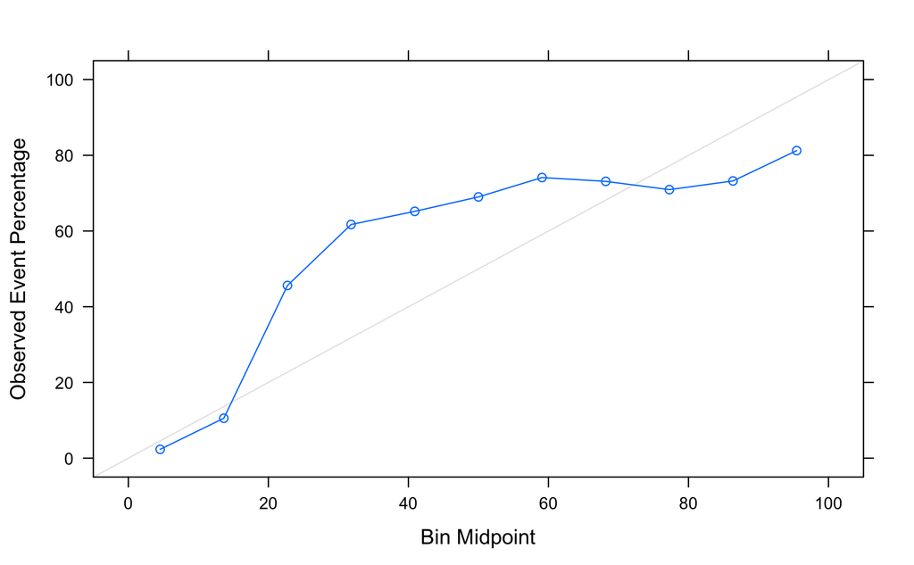

```r
# calibration plot
cal_data = calibration(aidaTest$Failed ~ lr.pconf, class="1")
xyplot(cal_data)
```

```r
table(na.omit(down.aidaTrain)$Failed)
```

```
    0     1
19914 10067
```

```r
# resampling method
noresampling = trainControl(method="none")

lr.fit = train(Failed ~ ., data = na.omit(down.aidaTrain),
               method = "glmStepAIC", trControl=noresampling,
               # pass-trough options
               family=binomial(logit))
```

```
Start:  AIC=21535.73
.outcome ~ Year + Incorporation.year + `\`Banks/turnover\`` +
    Cash.Flowth + Cost.of.debit + `\`Current.liabilities/Tot.ass\`` +
    Current.ratio + `\`Debt/EBITDA.ratio\`` + `\`Debt/equity.ratio\`` +
    `\`EBITDA/Vendite\`` + EBITDAth + `\`Interest/Turnover\`` +
    Leverage + Liquidity.ratio + Net.financial.positionth + Net.working.capitalth +
    Number.of.employees + `\`Profit.(loss)th\`` + ROA + ROE +
    ROI + ROS + Solvency.ratio + `\`Total.assets.turnover.(times)\`` +
    Total.assetsth

                                        Df Deviance   AIC
- `\\`Total.assets.turnover.(times)\\``  1    21484 21534
- `\\`Profit.(loss)th\\``                1    21484 21534
- Cash.Flowth                            1    21484 21534
- Liquidity.ratio                        1    21484 21534
- Net.financial.positionth               1    21484 21534
- `\\`Debt/EBITDA.ratio\\``              1    21484 21534
- ROI                                    1    21484 21534
- Leverage                               1    21484 21534
- Total.assetsth                         1    21484 21534
- ROS                                    1    21484 21534
- `\\`Debt/equity.ratio\\``              1    21484 21534
- EBITDAth                               1    21484 21534
- Number.of.employees                    1    21484 21534
<none>                                        21484 21536
- `\\`Interest/Turnover\\``              1    21486 21536
- Net.working.capitalth                  1    21486 21536
- `\\`Banks/turnover\\``                 1    21488 21538
- `\\`EBITDA/Vendite\\``                 1    21489 21539
- Current.ratio                          1    21493 21543
- Cost.of.debit                          1    21498 21548
- ROE                                    1    21499 21549
- Incorporation.year                     1    21504 21554
- ROA                                    1    21507 21557
- Solvency.ratio                         1    21527 21577
- `\\`Current.liabilities/Tot.ass\\``    1    21546 21596
- Year                                   1    34414 34464

Step:  AIC=21533.73
.outcome ~ Year + Incorporation.year + `\`Banks/turnover\`` +
```

[output cut: 330 more lines]

```
                                      Df Deviance   AIC
<none>                                      21487 21515
- `\\`Interest/Turnover\\``            1    21490 21516
- Leverage                             1    21490 21516
- `\\`Banks/turnover\\``               1    21492 21518
- `\\`EBITDA/Vendite\\``               1    21493 21519
- Net.working.capitalth                1    21495 21521
- ROE                                  1    21503 21529
- Cost.of.debit                        1    21503 21529
- Incorporation.year                   1    21508 21534
- Current.ratio                        1    21512 21538
- Solvency.ratio                       1    21540 21566
- ROA                                  1    21546 21572
- `\\`Current.liabilities/Tot.ass\\``  1    21554 21580
- Year                                 1    34497 34523
```

```r
lr.fit
```

```
Generalized Linear Model with Stepwise Feature Selection

29981 samples
   25 predictor
    2 classes: '0', '1'

No pre-processing
Resampling: None
```

```r
summary(lr.fit)
```

```
Call:
NULL

Deviance Residuals:
    Min       1Q   Median       3Q      Max
-3.3995  -0.5069  -0.3526   0.3729   2.7598

Coefficients:
                                      Estimate Std. Error z value Pr(>|z|)
(Intercept)                          1.106e+03  1.355e+01  81.647  < 2e-16 ***
Year                                -5.566e-01  6.573e-03 -84.673  < 2e-16 ***
Incorporation.year                   6.713e-03  1.498e-03   4.482 7.39e-06 ***
`\\`Banks/turnover\\``               3.243e-03  1.451e-03   2.235   0.0254 *
Cost.of.debit                        2.172e-02  5.542e-03   3.919 8.87e-05 ***
`\\`Current.liabilities/Tot.ass\\``  8.241e-01  1.016e-01   8.113 4.93e-16 ***
Current.ratio                        1.064e-01  2.131e-02   4.990 6.04e-07 ***
`\\`EBITDA/Vendite\\``              -5.588e-03  2.434e-03  -2.296   0.0217 *
`\\`Interest/Turnover\\``            2.943e-02  1.874e-02   1.571   0.1163
Leverage                             4.107e-04  2.561e-04   1.603   0.1088
Net.working.capitalth               -6.019e-06  2.864e-06  -2.101   0.0356 *
ROA                                 -3.684e-02  4.836e-03  -7.617 2.59e-14 ***
ROE                                 -2.873e-03  7.361e-04  -3.903 9.50e-05 ***
Solvency.ratio                      -8.456e-03  1.175e-03  -7.195 6.24e-13 ***
---
Signif. codes:  0 ‘***’ 0.001 ‘**’ 0.01 ‘*’ 0.05 ‘.’ 0.1 ‘ ’ 1

(Dispersion parameter for binomial family taken to be 1)

    Null deviance: 38268  on 29980  degrees of freedom
Residual deviance: 21487  on 29967  degrees of freedom
AIC: 21515

Number of Fisher Scoring iterations: 5
```

```r
aidaTest = na.omit(aidaTest)

# predicted confidence on validation set
lr.pred = predict(lr.fit, newdata = aidaTest, type="raw")
lr.prob = predict(lr.fit, newdata = aidaTest, type="prob") # as predict_proba in scikit-learn
lr.pconf = lr.prob[,2]
# built-in metrics
confusionMatrix(lr.pred, aidaTest$Failed, positive="1", mode = "prec_recall")
```

```
Confusion Matrix and Statistics

          Reference
Prediction     0     1
         0 13235  1147
         1  1116  3120

               Accuracy : 0.8785
                 95% CI : (0.8737, 0.8831)
    No Information Rate : 0.7708
    P-Value [Acc > NIR] : <2e-16

                  Kappa : 0.6551

 Mcnemar's Test P-Value : 0.5283

              Precision : 0.7365
                 Recall : 0.7312
                     F1 : 0.7339
             Prevalence : 0.2292
         Detection Rate : 0.1676
   Detection Prevalence : 0.2275
      Balanced Accuracy : 0.8267

       'Positive' Class : 1
```

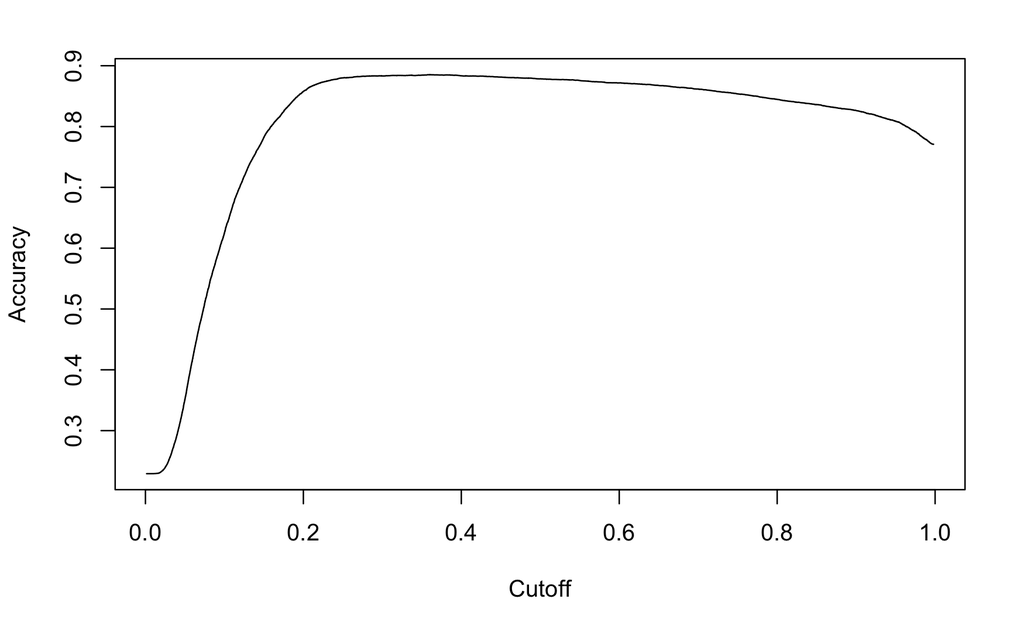

```r
# using ROCR for metrics at cutoff
library(ROCR)
lr.prediction = prediction(lr.pconf, aidaTest$Failed)
# acc at cutoff
lr.acc = performance(lr.prediction, "acc"); plot(lr.acc)
```

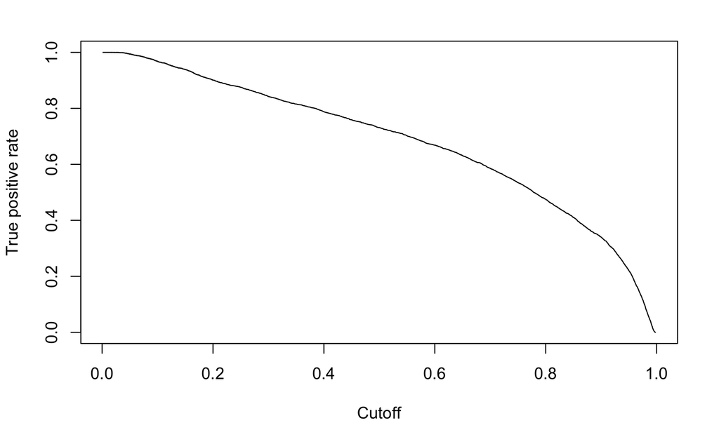

```r
# tpr (recall) at cutoff
lr.tpr = performance(lr.prediction, "tpr"); plot(lr.tpr)
```

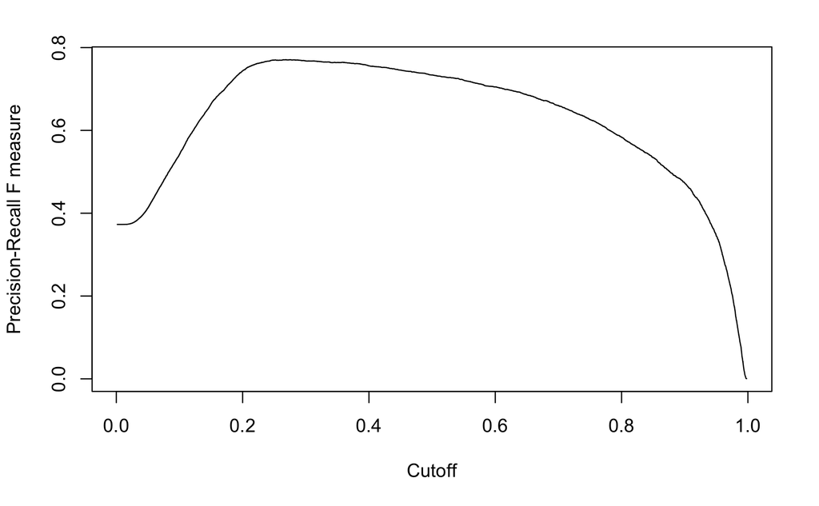

```r
# f1 at cutoff
lr.f1 = performance(lr.prediction, "f"); plot(lr.f1)
```

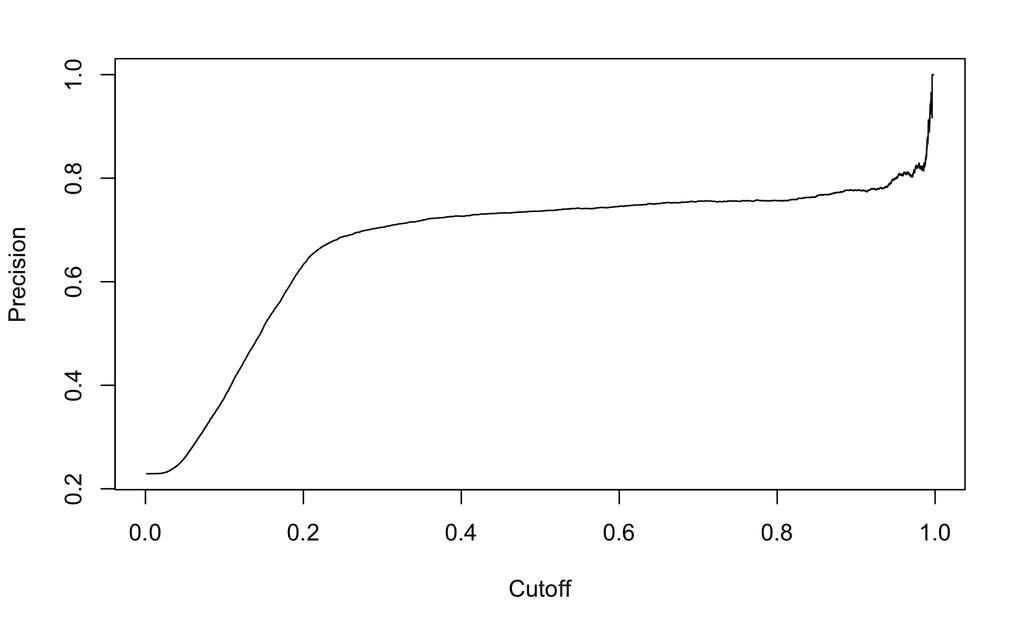

```r
# precision at cutoff
lr.prec = performance(lr.prediction, "prec"); plot(lr.prec)
```

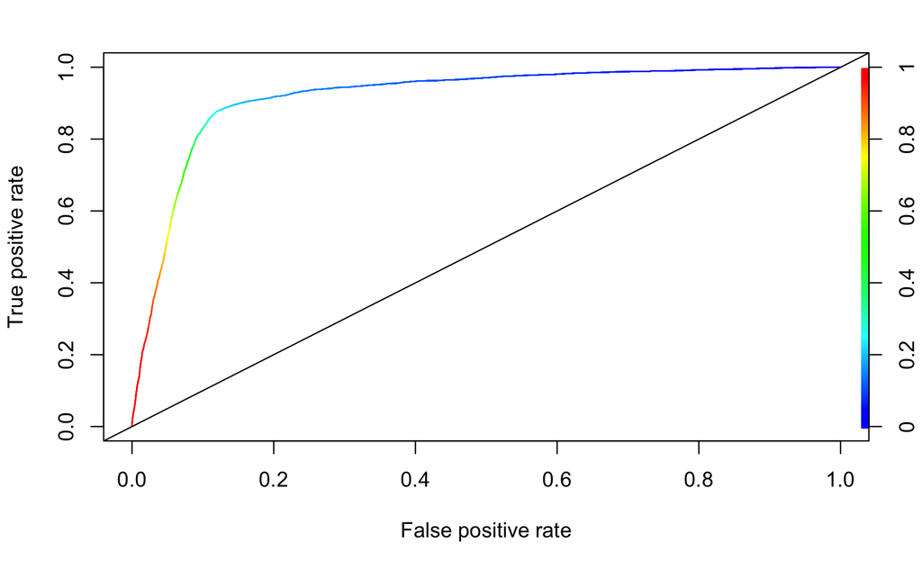

```r
# roc curve
lr.roc = performance(lr.prediction, "tpr", "fpr")
plot(lr.roc, colorize=T); abline(a=0, b= 1)
```

```r
# AUC: performance returns an object whose members (called 'slots') are accessed with '@'
o = performance(lr.prediction, "auc")
o@y.values[[1]]
```

```
[1] 0.9183316
```

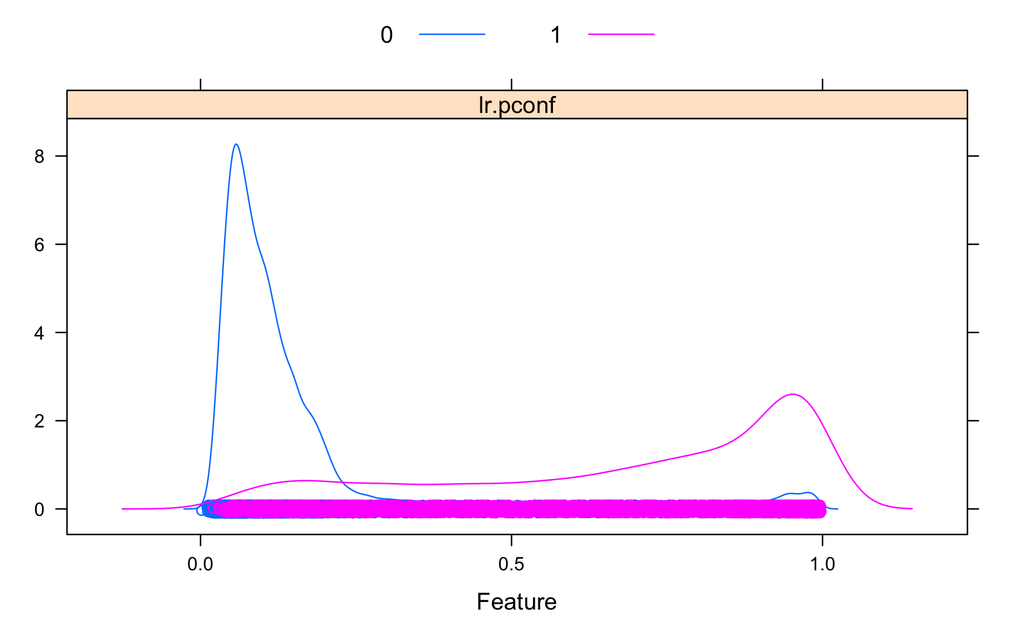

```r
featurePlot(x=data.frame(lr.pconf), y=aidaTest$Failed, plot='density', auto.key = list(columns = 2))
```

Con decision threshold a 0.3 F1-score migliore (aumenta molto il valore di Recall)

```r
cutoff = 0.3
lr.pred.cutoff = factor(ifelse(lr.pconf>=cutoff, 1, 0), levels=levels(aidaTest$Failed))
confusionMatrix(lr.pred.cutoff, aidaTest$Failed, positive="1", mode = "prec_recall")
```

```
Confusion Matrix and Statistics

          Reference
Prediction     0     1
         0 12849   672
         1  1502  3595

               Accuracy : 0.8832
                 95% CI : (0.8785, 0.8878)
    No Information Rate : 0.7708
    P-Value [Acc > NIR] : < 2.2e-16

                  Kappa : 0.6907

 Mcnemar's Test P-Value : < 2.2e-16

              Precision : 0.7053
                 Recall : 0.8425
                     F1 : 0.7678
             Prevalence : 0.2292
         Detection Rate : 0.1931
   Detection Prevalence : 0.2738
      Balanced Accuracy : 0.8689

       'Positive' Class : 1
```

Elastic Net Regularization using glmnet

```r
elasticFit <- cv.glmnet(x, y, family = "binomial")
```

[output not shown]

[figure not shown]

lambda.min is the value of lambda that gives the minimum mean cross-validated error lambda.1se is the value of lambda that gives the most regularized model

```r
print(elasticFit)
```

[output not shown]

```r
elas.prob = predict(elasticFit, newx = data.matrix(x.test), type="")
```

[output not shown]

Logistic Regression usando cross validation con custom summary function

```r
f1 <- function(data, lev = NULL, model = NULL) {
  f1_val <- F_meas(data$pred, data$obs, relevant="1")
  c(F1 = f1_val)
}

# repeated cross validation
rcv = trainControl(method="repeatedcv", repeats=5, number=10, summaryFunction = f1)
lr2.fit = train(Failed ~ ., data = na.omit(aidaTrain),
                method = "glm", trControl=rcv, metric="F1",
                allowParallel=TRUE,
                family=binomial(logit))
```

[output not shown]

[output cut: 46 more lines]

[output not shown]

[output not shown]

[output not shown]